# Project: Data Analyis of TMDb movie dataset (UDACITY)

*by Carla Mota Leal*

- Introduction
- Data Wrangling
- Exploratory Data Analysis
- Conclusions

## Introduction

> This data set contains information about 10000 movies collected from The Movie Database (TMDb), including user ratings and revenue.
- Certain columns, like ‘cast’ and ‘genres’, contain multiple values separated by pipe (|) characters.
- There are some odd characters in the ‘cast’ column. Don’t worry about cleaning them. You can leave them as is.
- The final two columns ending with “_adj” show the budget and revenue of the associated movie in terms of 2010 dollars, accounting for inflation over time.

```python
#loading necessary libraries

import pandas as pd
import numpy as np
import seaborn as sns
import matplotlib.pyplot as plt
%matplotlib inline
```

## Data Wrangling

> **Information from dataset**: There's 21 columns and 10866 entries, which 9 columns has different entries. In the column *imdb_id* they starts with 'tt'- characterized as obrject; In the column *cast*, *genres* and *production_companies*: the names are separeted by '|'; In the column *release_date*: needs to be converted to_datetime.

### General Properties

```python
# Load data

df = pd.read_csv('tmdb-movies.csv')

#Printing data columns
print(list(df.columns.values))
```

```
['id', 'imdb_id', 'popularity', 'budget', 'revenue', 'original_title', 'cast', 'homepage', 'director', 'tagline', 'keywords', 'overview', 'runtime', 'genres', 'production_companies', 'release_date', 'vote_count', 'vote_average', 'release_year', 'budget_adj', 'revenue_adj']
```

```python
#data info
df.info()
#float64(4), int64(6), object(11)
#10866 entries, 21 columns
```

```
<class 'pandas.core.frame.DataFrame'>
RangeIndex: 10866 entries, 0 to 10865
Data columns (total 21 columns):
 #   Column                Non-Null Count  Dtype
---  ------                --------------  -----
 0   id                    10866 non-null  int64
 1   imdb_id               10856 non-null  object
 2   popularity            10866 non-null  float64
 3   budget                10866 non-null  int64
 4   revenue               10866 non-null  int64
 5   original_title        10866 non-null  object
 6   cast                  10790 non-null  object
 7   homepage              2936 non-null   object
 8   director              10822 non-null  object
 9   tagline               8042 non-null   object
 10  keywords              9373 non-null   object
 11  overview              10862 non-null  object
 12  runtime               10866 non-null  int64
 13  genres                10843 non-null  object
 14  production_companies  9836 non-null   object
 15  release_date          10866 non-null  object
 16  vote_count            10866 non-null  int64
 17  vote_average          10866 non-null  float64
 18  release_year          10866 non-null  int64
 19  budget_adj            10866 non-null  float64
 20  revenue_adj           10866 non-null  float64
dtypes: float64(4), int64(6), object(11)
memory usage: 1.7+ MB
```

```python
#check the first 10 rows to observe how the dataset in composed

df.head(10)
```

|  | id | imdb_id | popularity | budget | revenue | original_title | cast | homepage | director | tagline | ... | overview | runtime | genres | production_companies | release_date | vote_count | vote_average | release_year | budget_adj | revenue_adj |
| --- | --- | --- | --- | --- | --- | --- | --- | --- | --- | --- | --- | --- | --- | --- | --- | --- | --- | --- | --- | --- | --- |
| 0 | 135397 | tt0369610 | 32.985763 | 150000000 | 1513528810 | Jurassic World | Chris Pratt\|Bryce Dallas Howard\|Irrfan Khan\|Vi... | http://www.jurassicworld.com/ | Colin Trevorrow | The park is open. | ... | Twenty-two years after the events of Jurassic ... | 124 | Action\|Adventure\|Science Fiction\|Thriller | Universal Studios\|Amblin Entertainment\|Legenda... | 6/9/15 | 5562 | 6.5 | 2015 | 1.379999e+08 | 1.392446e+09 |
| 1 | 76341 | tt1392190 | 28.419936 | 150000000 | 378436354 | Mad Max: Fury Road | Tom Hardy\|Charlize Theron\|Hugh Keays-Byrne\|Nic... | http://www.madmaxmovie.com/ | George Miller | What a Lovely Day. | ... | An apocalyptic story set in the furthest reach... | 120 | Action\|Adventure\|Science Fiction\|Thriller | Village Roadshow Pictures\|Kennedy Miller Produ... | 5/13/15 | 6185 | 7.1 | 2015 | 1.379999e+08 | 3.481613e+08 |
| 2 | 262500 | tt2908446 | 13.112507 | 110000000 | 295238201 | Insurgent | Shailene Woodley\|Theo James\|Kate Winslet\|Ansel... | http://www.thedivergentseries.movie/#insurgent | Robert Schwentke | One Choice Can Destroy You | ... | Beatrice Prior must confront her inner demons ... | 119 | Adventure\|Science Fiction\|Thriller | Summit Entertainment\|Mandeville Films\|Red Wago... | 3/18/15 | 2480 | 6.3 | 2015 | 1.012000e+08 | 2.716190e+08 |
| 3 | 140607 | tt2488496 | 11.173104 | 200000000 | 2068178225 | Star Wars: The Force Awakens | Harrison Ford\|Mark Hamill\|Carrie Fisher\|Adam D... | http://www.starwars.com/films/star-wars-episod... | J.J. Abrams | Every generation has a story. | ... | Thirty years after defeating the Galactic Empi... | 136 | Action\|Adventure\|Science Fiction\|Fantasy | Lucasfilm\|Truenorth Productions\|Bad Robot | 12/15/15 | 5292 | 7.5 | 2015 | 1.839999e+08 | 1.902723e+09 |
| 4 | 168259 | tt2820852 | 9.335014 | 190000000 | 1506249360 | Furious 7 | Vin Diesel\|Paul Walker\|Jason Statham\|Michelle ... | http://www.furious7.com/ | James Wan | Vengeance Hits Home | ... | Deckard Shaw seeks revenge against Dominic Tor... | 137 | Action\|Crime\|Thriller | Universal Pictures\|Original Film\|Media Rights ... | 4/1/15 | 2947 | 7.3 | 2015 | 1.747999e+08 | 1.385749e+09 |
| 5 | 281957 | tt1663202 | 9.110700 | 135000000 | 532950503 | The Revenant | Leonardo DiCaprio\|Tom Hardy\|Will Poulter\|Domhn... | http://www.foxmovies.com/movies/the-revenant | Alejandro González Iñárritu | (n. One who has returned, as if from the dead.) | ... | In the 1820s, a frontiersman, Hugh Glass, sets... | 156 | Western\|Drama\|Adventure\|Thriller | Regency Enterprises\|Appian Way\|CatchPlay\|Anony... | 12/25/15 | 3929 | 7.2 | 2015 | 1.241999e+08 | 4.903142e+08 |
| 6 | 87101 | tt1340138 | 8.654359 | 155000000 | 440603537 | Terminator Genisys | Arnold Schwarzenegger\|Jason Clarke\|Emilia Clar... | http://www.terminatormovie.com/ | Alan Taylor | Reset the future | ... | The year is 2029. John Connor, leader of the r... | 125 | Science Fiction\|Action\|Thriller\|Adventure | Paramount Pictures\|Skydance Productions | 6/23/15 | 2598 | 5.8 | 2015 | 1.425999e+08 | 4.053551e+08 |
| 7 | 286217 | tt3659388 | 7.667400 | 108000000 | 595380321 | The Martian | Matt Damon\|Jessica Chastain\|Kristen Wiig\|Jeff ... | http://www.foxmovies.com/movies/the-martian | Ridley Scott | Bring Him Home | ... | During a manned mission to Mars, Astronaut Mar... | 141 | Drama\|Adventure\|Science Fiction | Twentieth Century Fox Film Corporation\|Scott F... | 9/30/15 | 4572 | 7.6 | 2015 | 9.935996e+07 | 5.477497e+08 |
| 8 | 211672 | tt2293640 | 7.404165 | 74000000 | 1156730962 | Minions | Sandra Bullock\|Jon Hamm\|Michael Keaton\|Allison... | http://www.minionsmovie.com/ | Kyle Balda\|Pierre Coffin | Before Gru, they had a history of bad bosses | ... | Minions Stuart, Kevin and Bob are recruited by... | 91 | Family\|Animation\|Adventure\|Comedy | Universal Pictures\|Illumination Entertainment | 6/17/15 | 2893 | 6.5 | 2015 | 6.807997e+07 | 1.064192e+09 |
| 9 | 150540 | tt2096673 | 6.326804 | 175000000 | 853708609 | Inside Out | Amy Poehler\|Phyllis Smith\|Richard Kind\|Bill Ha... | http://movies.disney.com/inside-out | Pete Docter | Meet the little voices inside your head. | ... | Growing up can be a bumpy road, and it's no ex... | 94 | Comedy\|Animation\|Family | Walt Disney Pictures\|Pixar Animation Studios\|W... | 6/9/15 | 3935 | 8.0 | 2015 | 1.609999e+08 | 7.854116e+08 |

10 rows × 21 columns

```python
#summary descriptive data statistics
df.describe()
```

|  | id | popularity | budget | revenue | runtime | vote_count | vote_average | release_year | budget_adj | revenue_adj |
| --- | --- | --- | --- | --- | --- | --- | --- | --- | --- | --- |
| count | 10866.000000 | 10866.000000 | 1.086600e+04 | 1.086600e+04 | 10866.000000 | 10866.000000 | 10866.000000 | 10866.000000 | 1.086600e+04 | 1.086600e+04 |
| mean | 66064.177434 | 0.646441 | 1.462570e+07 | 3.982332e+07 | 102.070863 | 217.389748 | 5.974922 | 2001.322658 | 1.755104e+07 | 5.136436e+07 |
| std | 92130.136561 | 1.000185 | 3.091321e+07 | 1.170035e+08 | 31.381405 | 575.619058 | 0.935142 | 12.812941 | 3.430616e+07 | 1.446325e+08 |
| min | 5.000000 | 0.000065 | 0.000000e+00 | 0.000000e+00 | 0.000000 | 10.000000 | 1.500000 | 1960.000000 | 0.000000e+00 | 0.000000e+00 |
| 25% | 10596.250000 | 0.207583 | 0.000000e+00 | 0.000000e+00 | 90.000000 | 17.000000 | 5.400000 | 1995.000000 | 0.000000e+00 | 0.000000e+00 |
| 50% | 20669.000000 | 0.383856 | 0.000000e+00 | 0.000000e+00 | 99.000000 | 38.000000 | 6.000000 | 2006.000000 | 0.000000e+00 | 0.000000e+00 |
| 75% | 75610.000000 | 0.713817 | 1.500000e+07 | 2.400000e+07 | 111.000000 | 145.750000 | 6.600000 | 2011.000000 | 2.085325e+07 | 3.369710e+07 |
| max | 417859.000000 | 32.985763 | 4.250000e+08 | 2.781506e+09 | 900.000000 | 9767.000000 | 9.200000 | 2015.000000 | 4.250000e+08 | 2.827124e+09 |

in budget and revenue columns there's zero values

imdb_id: Similar to the id column, this is another unique identifier for each movie, but specific to IMDb. It's not useful for most analyses.  
homepage: The URL of the movie's official website. This is usually not relevant for data analysis purposes.  
tagline: A short description or slogan for the movie. It might not be useful for most analyses, but could be interesting for text analysis or natural language processing tasks.  
overview: A longer description of the movie's plot. Like the tagline, it might not be useful for most analyses but could be interesting for text analysis or natural language processing tasks.

### Data Cleaning

- Drop the duplicated rows.
- Drop the rows which have missing values.
- Change the format of release date into DateTime format.
- Delete the unused columns from Data Frame
- Checking the all columns are in the desired data type.
- Calculating the profit extracting revenue from the budget.

```python
#Drop unnecessary columns
df.drop(columns=['homepage','tagline','overview','keywords','imdb_id'], inplace=True)
```

```python
df.head()
```

|  | id | popularity | budget | revenue | original_title | cast | director | runtime | genres | production_companies | release_date | vote_count | vote_average | release_year | budget_adj | revenue_adj |
| --- | --- | --- | --- | --- | --- | --- | --- | --- | --- | --- | --- | --- | --- | --- | --- | --- |
| 0 | 135397 | 32.985763 | 150000000 | 1513528810 | Jurassic World | Chris Pratt\|Bryce Dallas Howard\|Irrfan Khan\|Vi... | Colin Trevorrow | 124 | Action\|Adventure\|Science Fiction\|Thriller | Universal Studios\|Amblin Entertainment\|Legenda... | 6/9/15 | 5562 | 6.5 | 2015 | 1.379999e+08 | 1.392446e+09 |
| 1 | 76341 | 28.419936 | 150000000 | 378436354 | Mad Max: Fury Road | Tom Hardy\|Charlize Theron\|Hugh Keays-Byrne\|Nic... | George Miller | 120 | Action\|Adventure\|Science Fiction\|Thriller | Village Roadshow Pictures\|Kennedy Miller Produ... | 5/13/15 | 6185 | 7.1 | 2015 | 1.379999e+08 | 3.481613e+08 |
| 2 | 262500 | 13.112507 | 110000000 | 295238201 | Insurgent | Shailene Woodley\|Theo James\|Kate Winslet\|Ansel... | Robert Schwentke | 119 | Adventure\|Science Fiction\|Thriller | Summit Entertainment\|Mandeville Films\|Red Wago... | 3/18/15 | 2480 | 6.3 | 2015 | 1.012000e+08 | 2.716190e+08 |
| 3 | 140607 | 11.173104 | 200000000 | 2068178225 | Star Wars: The Force Awakens | Harrison Ford\|Mark Hamill\|Carrie Fisher\|Adam D... | J.J. Abrams | 136 | Action\|Adventure\|Science Fiction\|Fantasy | Lucasfilm\|Truenorth Productions\|Bad Robot | 12/15/15 | 5292 | 7.5 | 2015 | 1.839999e+08 | 1.902723e+09 |
| 4 | 168259 | 9.335014 | 190000000 | 1506249360 | Furious 7 | Vin Diesel\|Paul Walker\|Jason Statham\|Michelle ... | James Wan | 137 | Action\|Crime\|Thriller | Universal Pictures\|Original Film\|Media Rights ... | 4/1/15 | 2947 | 7.3 | 2015 | 1.747999e+08 | 1.385749e+09 |

```python
#Find missing data count for each feature:
df.isnull().sum()
```

```
id                         0
popularity                 0
budget                     0
revenue                    0
original_title             0
cast                      76
director                  44
runtime                    0
genres                    23
production_companies    1030
release_date               0
vote_count                 0
vote_average               0
release_year               0
budget_adj                 0
revenue_adj                0
dtype: int64
```

```python
###Drop missing data
#keeping only movies, that has casted actors and has genre
null_cast_indices = df[df['cast'].isnull()].index
df.drop(null_cast_indices, inplace=True)

null_genres_indices = df[df['genres'].isnull()].index
df.drop(null_genres_indices, inplace=True)
```

```python
#also removing rows where revenue_adj and budget_adj is equal to zero (as seen in descriptive statistics)
df = df[df.budget_adj != 0]
df = df[df.revenue_adj != 0]
```

```python
#checking for descriptive statistics again
df.describe()
```

|  | id | popularity | budget | revenue | runtime | vote_count | vote_average | release_year | budget_adj | revenue_adj |
| --- | --- | --- | --- | --- | --- | --- | --- | --- | --- | --- |
| count | 3850.000000 | 3850.000000 | 3.850000e+03 | 3.850000e+03 | 3850.000000 | 3850.000000 | 3850.000000 | 3850.000000 | 3.850000e+03 | 3.850000e+03 |
| mean | 39878.804416 | 1.192661 | 3.724027e+07 | 1.077897e+08 | 109.228831 | 528.252727 | 6.168597 | 2001.260000 | 4.428320e+07 | 1.371986e+08 |
| std | 67241.305740 | 1.475527 | 4.221487e+07 | 1.766015e+08 | 19.924053 | 880.258758 | 0.794616 | 11.284699 | 4.481243e+07 | 2.161832e+08 |
| min | 5.000000 | 0.001117 | 1.000000e+00 | 2.000000e+00 | 15.000000 | 10.000000 | 2.200000 | 1960.000000 | 9.693980e-01 | 2.370705e+00 |
| 25% | 6072.250000 | 0.463201 | 1.000000e+07 | 1.363273e+07 | 95.250000 | 71.000000 | 5.700000 | 1995.000000 | 1.314346e+07 | 1.841498e+07 |
| 50% | 11316.000000 | 0.798343 | 2.400000e+07 | 4.488472e+07 | 106.000000 | 204.500000 | 6.200000 | 2004.000000 | 3.004524e+07 | 6.179073e+07 |
| 75% | 38573.250000 | 1.372826 | 5.000000e+07 | 1.242969e+08 | 119.000000 | 580.750000 | 6.700000 | 2010.000000 | 6.072867e+07 | 1.633775e+08 |
| max | 417859.000000 | 32.985763 | 4.250000e+08 | 2.781506e+09 | 338.000000 | 9767.000000 | 8.400000 | 2015.000000 | 4.250000e+08 | 2.827124e+09 |

now budget and revenue has clear values

```python
#Check for duplicates
df.duplicated().sum()
```

```
1
```

```python
#drop the one duplicate
df.drop_duplicates(inplace=True)
```

let's check if that worked!

```python
df.duplicated().sum()
```

```
0
```

```python
df.info()
```

[output not shown]

### changing columns to the right data type

```python
df['release_date'] = pd.to_datetime(df['release_date'])
df['release_date'].head()
```

```
0   2015-06-09
1   2015-05-13
2   2015-03-18
3   2015-12-15
4   2015-04-01
Name: release_date, dtype: datetime64[ns]
```

### Checking if the dataset contains runtime of zero or less than zero

```python
is_runtime_zero = df['runtime'] == 0
df[is_runtime_zero].shape , df[is_runtime_zero].index.values
```

```
((0, 16), array([], dtype=int64))
```

There's none so let's continue

## Exploratory Data Analysis

### Research Question 1: Who are the most famous actors?

```python
# Split the cast column into separate columns
df = df.join(df['cast'].str.split('|', expand=True).add_prefix('cast_'))

# Melt the cast columns into rows
df = pd.melt(df, id_vars=['original_title'], value_vars=['cast_0', 'cast_1', 'cast_2', 'cast_3', 'cast_4'], value_name='actor').dropna()

# Group by actor and count the number of movies in each group
actor_counts = df.groupby('actor').size().reset_index(name='count')

# Sort the actors by count in descending order
actor_counts = actor_counts.sort_values('count', ascending=False)

# Display the top 10 actors
print(actor_counts.head(10))
```

```
                  actor  count
5509     Robert De Niro     52
882        Bruce Willis     46
5782  Samuel L. Jackson     44
4862       Nicolas Cage     43
4380         Matt Damon     36
3282        Johnny Depp     35
2430      Harrison Ford     34
6444          Tom Hanks     34
781           Brad Pitt     34
4725     Morgan Freeman     34
```

The most famous actor is Robert de Nirto with 52 original movies.

### Research Question 2: Which Movie Has The Highest profit?

First to calculate Profit for each of the movie:

```python
df['profit'] = df['revenue']-df['budget']
df['profit'] = df['profit'].apply(np.int64)
df['budget'] = df['budget'].apply(np.int64)
df['revenue'] = df['revenue'].apply(np.int64)
```

top ten profitable movies

```python
def top_10(col_name,size=10):
    #find the all times top 10 for a fiven column
    #sort the given column and select the top 10
    df_sorted = pd.DataFrame(df[col_name].sort_values(ascending=False))[:size]
    df_sorted['original_title'] = df['original_title']
    plt.figure(figsize=(12,6))
    #Calculate the avarage
    avg = np.mean(df[col_name])
    sns.barplot(x=col_name, y='original_title', data=df_sorted, label=col_name)
    plt.axvline(avg, color='k', linestyle='--', label='mean')
    if (col_name == 'profit' or col_name == 'budget' or col_name == 'revenue'):
        plt.xlabel(col_name.capitalize() + ' (U.S Dolar)')
    else:
        plt.xlabel(col_name.capitalize())
    plt.ylabel('')
    plt.title('Top 10 Movies in: ' + col_name.capitalize())
    plt.legend()
```

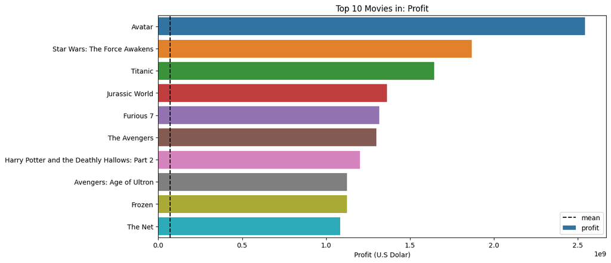

```python
top_10('profit')
```

```python
print(df['release_date'].min())
```

[output not shown]

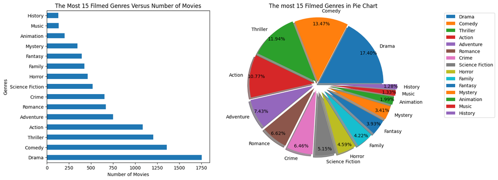

```python
from matplotlib import gridspec
def split_count_data(col_name, size=15):
    ##function which will take any column as argument from which data is need to be extracted and keep track of count
    #take a given column, and separate the string by '|'
    data = df[col_name].str.cat(sep='|')
    #storing the values separately in the series
    data = pd.Series(data.split('|'))
    #Let's count the most frequenties values for given column
    count = data.value_counts(ascending=False)
    count_size = count.head(size)
    #Setting axis name for multiple names
    if (col_name == 'production_companies'):
        sp = col_name.split('_')
        axis_name = sp[0].capitalize()+' '+ sp[1].capitalize()
    else:
        axis_name = col_name.capitalize()
    fig = plt.figure(figsize=(14, 6))
    #set the subplot
    gs = gridspec.GridSpec(1,2, width_ratios=[2,2])
    #count of given column on the bar plot
    ax0 = plt.subplot(gs[0])
    count_size.plot.barh()
    plt.xlabel('Number of Movies')
    plt.ylabel(axis_name)
    plt.title('The Most '+str(size)+' Filmed ' +axis_name+' Versus Number of Movies')
    ax = plt.subplot(gs[1])
    #setting the explode to adjust the pei chart explode variable to any given size
    explode = []
    total = 0
    for i in range(size):
         total = total + 0.015
         explode.append(total)
    #pie chart for given size and given column
    ax = count_size.plot.pie(autopct='%1.2f%%', shadow=True, startangle=0, pctdistance=0.9, explode=explode)
    plt.title('The most '+str(size)+' Filmed ' +axis_name+ ' in Pie Chart')
    plt.xlabel('')
    plt.ylabel('')
    plt.axis('equal')
    plt.legend(loc=9, bbox_to_anchor=(1.4, 1))

split_count_data("genres")
```

### Research Question 4: What are the relation between the Revenue, Popularity, and Rating?

Demonstration use of matplotlib plotbox:

```python
# Creating a function
def plot_box(feature):
    df.boxplot(feature, vert=False,showfliers=False)
```

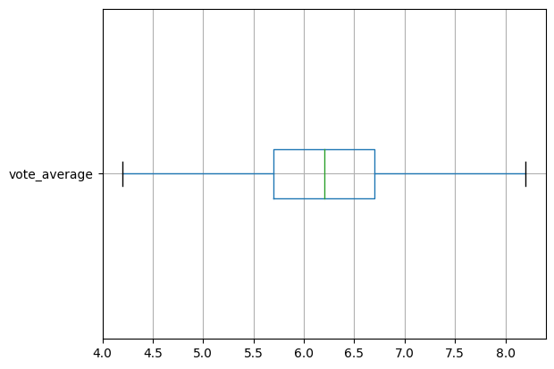

```python
# Distribution of Ratings:
plot_box('vote_average')
```

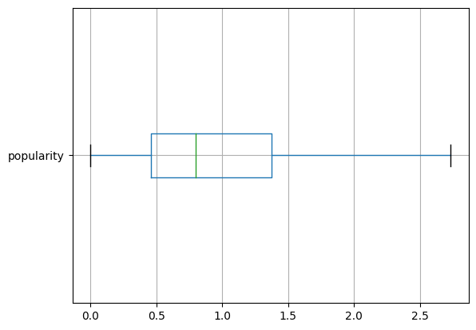

```python
# distribution of Popularity:
plot_box('popularity')
```

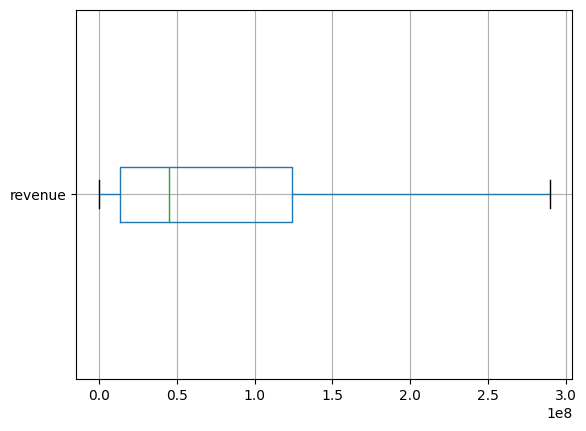

```python
# distribution of Revenue:
plot_box('revenue')
```

Correlation between Revenue vs Popularity using the matblotlib scatter-plot:

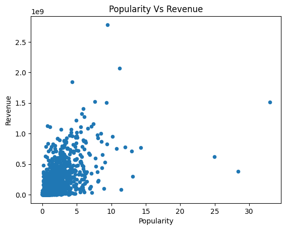

```python
# Scatter plot of Revenue vs Popularity
df.plot(x='popularity',y='revenue',kind='scatter')
plt.title('Popularity Vs Revenue')
plt.xlabel('Popularity')
plt.ylabel('Revenue');
```

Correlation between Popularity vs Ratings using the matblotlib scatter-plot:

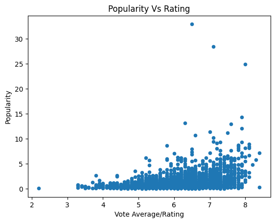

```python
# Scatter plot of Popularity vs Ratings
df.plot(x='vote_average',y='popularity',kind='scatter')
plt.title('Popularity Vs Rating')
plt.xlabel('Vote Average/Rating')
plt.ylabel('Popularity');
```

Correlation between Revenue vs Ratings using the matblotlib scatter-plot:

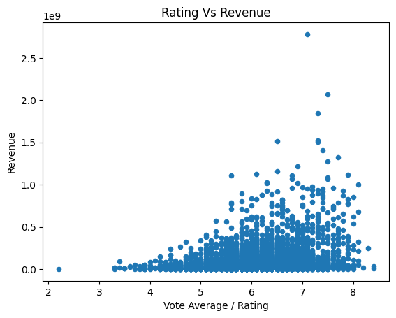

```python
# Scatter plot of Revenue vs Ratings:
df.plot(x='vote_average',y='revenue',kind='scatter')
plt.title('Rating Vs Revenue')
plt.xlabel('Vote Average / Rating')
plt.ylabel('Revenue');
```

# Conclusions

### Conclusions from the analysis performed:

> Although our dataset has more than 10,000 rows there were some limitations:
1. Majority of the data columns are irrelevant for the analysis
2. There's a lot of NaN values. A possible solution would be re-do a web scrapping for a better data quality or prepare data from a different source than the one we have.
3. As seen in the revenue and budget variables, there's a lot of 0-valued data, and after the cleaning step the data may not be representative.
4. Update the data would be very intesresting for a more up-to-date analysis.